# Diabetes Prediction

```python
import pandas as pd
import numpy as np
from scipy import stats

import seaborn  as sns
import matplotlib.pyplot as plt
from sklearn.metrics import plot_confusion_matrix

from sklearn.model_selection import train_test_split, cross_val_score,cross_val_predict, GridSearchCV, StratifiedKFold

from  sklearn.preprocessing import  FunctionTransformer
from sklearn.compose import ColumnTransformer
from sklearn.pipeline import make_pipeline

from sklearn.impute import SimpleImputer
from sklearn.preprocessing import StandardScaler, MinMaxScaler

from sklearn.linear_model import SGDClassifier
from sklearn.naive_bayes import GaussianNB
from xgboost import XGBClassifier
from sklearn.neighbors import KNeighborsClassifier
from sklearn.tree import DecisionTreeClassifier
from sklearn.ensemble import AdaBoostClassifier, GradientBoostingClassifier, RandomForestClassifier, ExtraTreesClassifier
from sklearn.ensemble import VotingClassifier
```

```python
data = pd.read_csv("C:\\Users\\Renz\\Desktop\\Data Science\\PIMA Diabetes Classification\\diabetes.csv")
data.head()
X = data.drop(columns = 'Outcome')
y = data['Outcome']
```

- Pregnancies : # times pregnant
- Glucose : (blood sugar level) a 2 hours in an oral glucose tolerance test
- BloodPressure : (mm Hg)
- SkinThickness : Triceps skin fold thickness (mm)
- Insulin : 2-Hour serum insulin (mu U/ml)
- BMI : Body mass index (weight in kg/(height in m)^2)
- DiabetesPedigreeFunction: Diabetes pedigree function
- Outcome: 1 = diabetic, 0 = no

```python
#check null values
data.isnull().sum()
```

```
Pregnancies                 0
Glucose                     0
BloodPressure               0
SkinThickness               0
Insulin                     0
BMI                         0
DiabetesPedigreeFunction    0
Age                         0
Outcome                     0
dtype: int64
```

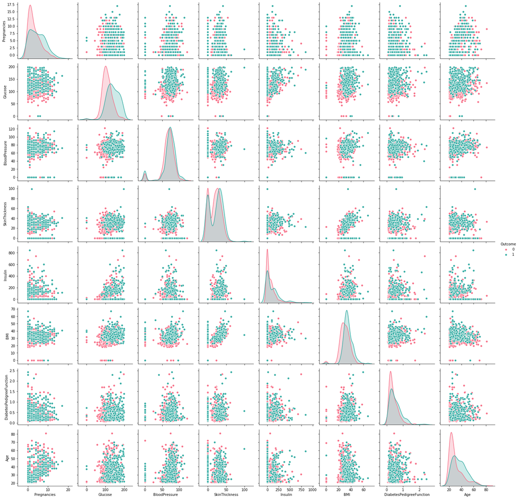

```python
sns.pairplot(data, hue="Outcome", palette="husl")
```

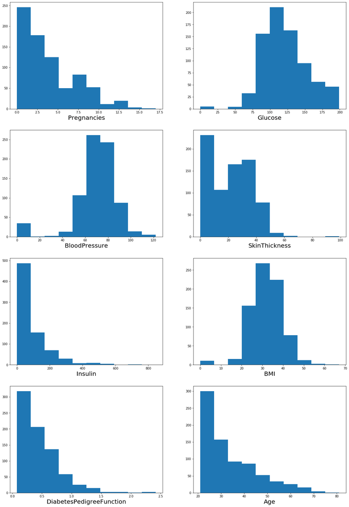

```python
#check distribution plots
fig = plt.figure(figsize = (20,30))
column_list = list(data.drop(columns = 'Outcome').columns)
for column in column_list:
    fig.add_subplot(4,2, column_list.index(column) +1)
    plt.hist(data[column])
    plt.xlabel(column, fontsize = 20)
```

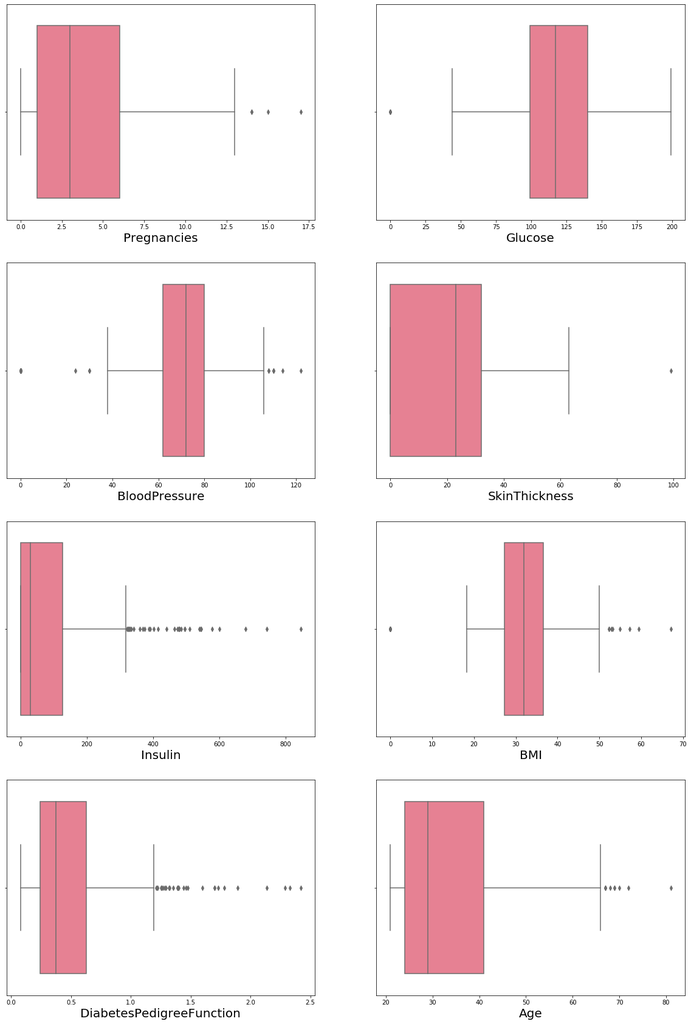

```python
#check outliers  with boxplots
fig = plt.figure(figsize = (20,30))
column_list = list(data.drop(columns = 'Outcome').columns)
for column in column_list:
    fig.add_subplot(4,2, column_list.index(column) +1)
    sns.boxplot(data[column], palette='husl')
    plt.xlabel(column, fontsize = 20)
```

glucose, blood pressure, bmi, skin thickness, insulin has '0' values which is weird. I want to check them out, they might be a candidate for bad data (remove)

```python
#0 glucose
glucose0 = data[data['Glucose'] == 0].index
data[data['Glucose'] == 0]
```

|  | Pregnancies | Glucose | BloodPressure | SkinThickness | Insulin | BMI | DiabetesPedigreeFunction | Age | Outcome |
| --- | --- | --- | --- | --- | --- | --- | --- | --- | --- |
| 75 | 1 | 0 | 48 | 20 | 0 | 24.7 | 0.140 | 22 | 0 |
| 182 | 1 | 0 | 74 | 20 | 23 | 27.7 | 0.299 | 21 | 0 |
| 342 | 1 | 0 | 68 | 35 | 0 | 32.0 | 0.389 | 22 | 0 |
| 349 | 5 | 0 | 80 | 32 | 0 | 41.0 | 0.346 | 37 | 1 |
| 502 | 6 | 0 | 68 | 41 | 0 | 39.0 | 0.727 | 41 | 1 |

```python
#0 bloodpressure
bp0 = data[data['BloodPressure'] == 0].index
data[data['BloodPressure'] == 0]
```

|  | Pregnancies | Glucose | BloodPressure | SkinThickness | Insulin | BMI | DiabetesPedigreeFunction | Age | Outcome |
| --- | --- | --- | --- | --- | --- | --- | --- | --- | --- |
| 7 | 10 | 115 | 0 | 0 | 0 | 35.3 | 0.134 | 29 | 0 |
| 15 | 7 | 100 | 0 | 0 | 0 | 30.0 | 0.484 | 32 | 1 |
| 49 | 7 | 105 | 0 | 0 | 0 | 0.0 | 0.305 | 24 | 0 |
| 60 | 2 | 84 | 0 | 0 | 0 | 0.0 | 0.304 | 21 | 0 |
| 78 | 0 | 131 | 0 | 0 | 0 | 43.2 | 0.270 | 26 | 1 |
| 81 | 2 | 74 | 0 | 0 | 0 | 0.0 | 0.102 | 22 | 0 |
| 172 | 2 | 87 | 0 | 23 | 0 | 28.9 | 0.773 | 25 | 0 |
| 193 | 11 | 135 | 0 | 0 | 0 | 52.3 | 0.578 | 40 | 1 |
| 222 | 7 | 119 | 0 | 0 | 0 | 25.2 | 0.209 | 37 | 0 |
| 261 | 3 | 141 | 0 | 0 | 0 | 30.0 | 0.761 | 27 | 1 |
| 266 | 0 | 138 | 0 | 0 | 0 | 36.3 | 0.933 | 25 | 1 |
| 269 | 2 | 146 | 0 | 0 | 0 | 27.5 | 0.240 | 28 | 1 |
| 300 | 0 | 167 | 0 | 0 | 0 | 32.3 | 0.839 | 30 | 1 |
| 332 | 1 | 180 | 0 | 0 | 0 | 43.3 | 0.282 | 41 | 1 |
| 336 | 0 | 117 | 0 | 0 | 0 | 33.8 | 0.932 | 44 | 0 |
| 347 | 3 | 116 | 0 | 0 | 0 | 23.5 | 0.187 | 23 | 0 |
| 357 | 13 | 129 | 0 | 30 | 0 | 39.9 | 0.569 | 44 | 1 |
| 426 | 0 | 94 | 0 | 0 | 0 | 0.0 | 0.256 | 25 | 0 |
| 430 | 2 | 99 | 0 | 0 | 0 | 22.2 | 0.108 | 23 | 0 |
| 435 | 0 | 141 | 0 | 0 | 0 | 42.4 | 0.205 | 29 | 1 |
| 453 | 2 | 119 | 0 | 0 | 0 | 19.6 | 0.832 | 72 | 0 |
| 468 | 8 | 120 | 0 | 0 | 0 | 30.0 | 0.183 | 38 | 1 |
| 484 | 0 | 145 | 0 | 0 | 0 | 44.2 | 0.630 | 31 | 1 |
| 494 | 3 | 80 | 0 | 0 | 0 | 0.0 | 0.174 | 22 | 0 |
| 522 | 6 | 114 | 0 | 0 | 0 | 0.0 | 0.189 | 26 | 0 |
| 533 | 6 | 91 | 0 | 0 | 0 | 29.8 | 0.501 | 31 | 0 |
| 535 | 4 | 132 | 0 | 0 | 0 | 32.9 | 0.302 | 23 | 1 |
| 589 | 0 | 73 | 0 | 0 | 0 | 21.1 | 0.342 | 25 | 0 |
| 601 | 6 | 96 | 0 | 0 | 0 | 23.7 | 0.190 | 28 | 0 |
| 604 | 4 | 183 | 0 | 0 | 0 | 28.4 | 0.212 | 36 | 1 |
| 619 | 0 | 119 | 0 | 0 | 0 | 32.4 | 0.141 | 24 | 1 |
| 643 | 4 | 90 | 0 | 0 | 0 | 28.0 | 0.610 | 31 | 0 |
| 697 | 0 | 99 | 0 | 0 | 0 | 25.0 | 0.253 | 22 | 0 |
| 703 | 2 | 129 | 0 | 0 | 0 | 38.5 | 0.304 | 41 | 0 |
| 706 | 10 | 115 | 0 | 0 | 0 | 0.0 | 0.261 | 30 | 1 |

```python
#0 bmi
bmi0 = data[data['BMI'] == 0].index
data[data['BMI'] == 0]
```

|  | Pregnancies | Glucose | BloodPressure | SkinThickness | Insulin | BMI | DiabetesPedigreeFunction | Age | Outcome |
| --- | --- | --- | --- | --- | --- | --- | --- | --- | --- |
| 9 | 8 | 125 | 96 | 0 | 0 | 0.0 | 0.232 | 54 | 1 |
| 49 | 7 | 105 | 0 | 0 | 0 | 0.0 | 0.305 | 24 | 0 |
| 60 | 2 | 84 | 0 | 0 | 0 | 0.0 | 0.304 | 21 | 0 |
| 81 | 2 | 74 | 0 | 0 | 0 | 0.0 | 0.102 | 22 | 0 |
| 145 | 0 | 102 | 75 | 23 | 0 | 0.0 | 0.572 | 21 | 0 |
| 371 | 0 | 118 | 64 | 23 | 89 | 0.0 | 1.731 | 21 | 0 |
| 426 | 0 | 94 | 0 | 0 | 0 | 0.0 | 0.256 | 25 | 0 |
| 494 | 3 | 80 | 0 | 0 | 0 | 0.0 | 0.174 | 22 | 0 |
| 522 | 6 | 114 | 0 | 0 | 0 | 0.0 | 0.189 | 26 | 0 |
| 684 | 5 | 136 | 82 | 0 | 0 | 0.0 | 0.640 | 69 | 0 |
| 706 | 10 | 115 | 0 | 0 | 0 | 0.0 | 0.261 | 30 | 1 |

```python
#0 skinthickness
st0 = data[data['SkinThickness'] == 0].index
data[data['SkinThickness'] == 0]
```

|  | Pregnancies | Glucose | BloodPressure | SkinThickness | Insulin | BMI | DiabetesPedigreeFunction | Age | Outcome |
| --- | --- | --- | --- | --- | --- | --- | --- | --- | --- |
| 2 | 8 | 183 | 64 | 0 | 0 | 23.3 | 0.672 | 32 | 1 |
| 5 | 5 | 116 | 74 | 0 | 0 | 25.6 | 0.201 | 30 | 0 |
| 7 | 10 | 115 | 0 | 0 | 0 | 35.3 | 0.134 | 29 | 0 |
| 9 | 8 | 125 | 96 | 0 | 0 | 0.0 | 0.232 | 54 | 1 |
| 10 | 4 | 110 | 92 | 0 | 0 | 37.6 | 0.191 | 30 | 0 |
| ... | ... | ... | ... | ... | ... | ... | ... | ... | ... |
| 757 | 0 | 123 | 72 | 0 | 0 | 36.3 | 0.258 | 52 | 1 |
| 758 | 1 | 106 | 76 | 0 | 0 | 37.5 | 0.197 | 26 | 0 |
| 759 | 6 | 190 | 92 | 0 | 0 | 35.5 | 0.278 | 66 | 1 |
| 762 | 9 | 89 | 62 | 0 | 0 | 22.5 | 0.142 | 33 | 0 |
| 766 | 1 | 126 | 60 | 0 | 0 | 30.1 | 0.349 | 47 | 1 |

227 rows × 9 columns

```python
#0 insulin
insulin0 = data[data['Insulin'] == 0].index
data[data['Insulin'] == 0]
```

|  | Pregnancies | Glucose | BloodPressure | SkinThickness | Insulin | BMI | DiabetesPedigreeFunction | Age | Outcome |
| --- | --- | --- | --- | --- | --- | --- | --- | --- | --- |
| 0 | 6 | 148 | 72 | 35 | 0 | 33.6 | 0.627 | 50 | 1 |
| 1 | 1 | 85 | 66 | 29 | 0 | 26.6 | 0.351 | 31 | 0 |
| 2 | 8 | 183 | 64 | 0 | 0 | 23.3 | 0.672 | 32 | 1 |
| 5 | 5 | 116 | 74 | 0 | 0 | 25.6 | 0.201 | 30 | 0 |
| 7 | 10 | 115 | 0 | 0 | 0 | 35.3 | 0.134 | 29 | 0 |
| ... | ... | ... | ... | ... | ... | ... | ... | ... | ... |
| 761 | 9 | 170 | 74 | 31 | 0 | 44.0 | 0.403 | 43 | 1 |
| 762 | 9 | 89 | 62 | 0 | 0 | 22.5 | 0.142 | 33 | 0 |
| 764 | 2 | 122 | 70 | 27 | 0 | 36.8 | 0.340 | 27 | 0 |
| 766 | 1 | 126 | 60 | 0 | 0 | 30.1 | 0.349 | 47 | 1 |
| 767 | 1 | 93 | 70 | 31 | 0 | 30.4 | 0.315 | 23 | 0 |

374 rows × 9 columns

TESTING THESE WITH A MODEL:

- impute blood presure with a trimmed mean.
- impute insulin with a trimmed mean.
- impute skinthickness with a trimmed mean.

# In the end we did not do this because these features were not selected at all

```python
scores = pd.DataFrame(index = ['SGD','KNN', 'GNB', 'XGB','RFC','DTC','ADA','XTC','GBC'])
```

Baseline scores:

```python
def ModelScores(data,  suffix, scores):
    '''Returns the score dataframe given joined with the results of model testing of a new dataset provided'''
    X = data.drop(columns = 'Outcome')
    y = data['Outcome']
    models =[['SGD', SGDClassifier(random_state= 42)],
             ['KNN', KNeighborsClassifier()],
             ['GNB', GaussianNB()],
             ['XGB', XGBClassifier(random_state= 42)],
             ['RFC', RandomForestClassifier(random_state= 42)],
             ['DTC', DecisionTreeClassifier(random_state= 42)],
             ['ADA', AdaBoostClassifier(random_state= 42)],
             ['XTC', ExtraTreesClassifier(random_state= 42)],
             ['GBC', GradientBoostingClassifier(random_state= 42)]]
    Model = [x[0] for x in models]
    table = {'Accuracy'+suffix :[],
             'STD'+suffix : [],
             'Recall'+suffix : []}
    for name, model in models:
        kfold = StratifiedKFold(n_splits=10, random_state=42, shuffle = True)
        accuracy = cross_val_score(model, X, y, cv = kfold).mean()
        accuracyStd = cross_val_score(model, X, y, cv = kfold).std()
        recall = cross_val_score(model, X, y, cv = kfold, scoring = 'recall').mean()
        table['Accuracy'+suffix].append(accuracy)
        table['STD'+suffix].append(accuracyStd)
        table['Recall'+suffix].append(recall)
        msg = '%s : P = %f, PSTD = %f, R = %f' % (name, accuracy, accuracyStd, recall)
        print(msg)
    df = pd.DataFrame(table, index = Model)
    scores = scores.join(df)
    return scores
```

```python
scores = ModelScores(data,  '', scores)
```

```
SGD : P = 0.487338, PSTD = 0.128128, R = 0.811538
KNN : P = 0.710868, PSTD = 0.060392, R = 0.518519
GNB : P = 0.755161, PSTD = 0.050206, R = 0.608262
XGB : P = 0.765499, PSTD = 0.060417, R = 0.622650
RFC : P = 0.769498, PSTD = 0.044480, R = 0.600855
DTC : P = 0.702939, PSTD = 0.060909, R = 0.574501
ADA : P = 0.751213, PSTD = 0.046420, R = 0.585470
XTC : P = 0.757707, PSTD = 0.051041, R = 0.577778
GBC : P = 0.765516, PSTD = 0.056298, R = 0.608120
```

```python
scores
```

|  | Accuracy | STD | Recall |
| --- | --- | --- | --- |
| SGD | 0.487338 | 0.128128 | 0.811538 |
| KNN | 0.710868 | 0.060392 | 0.518519 |
| GNB | 0.755161 | 0.050206 | 0.608262 |
| XGB | 0.765499 | 0.060417 | 0.622650 |
| RFC | 0.769498 | 0.044480 | 0.600855 |
| DTC | 0.702939 | 0.060909 | 0.574501 |
| ADA | 0.751213 | 0.046420 | 0.585470 |
| XTC | 0.757707 | 0.051041 | 0.577778 |
| GBC | 0.765516 | 0.056298 | 0.608120 |

```python
pd.DataFrame(data.corr()['Outcome']).sort_values(by = ['Outcome'], ascending = False)
```

|  | Outcome |
| --- | --- |
| Outcome | 1.000000 |
| Glucose | 0.466581 |
| BMI | 0.292695 |
| Age | 0.238356 |
| Pregnancies | 0.221898 |
| DiabetesPedigreeFunction | 0.173844 |
| Insulin | 0.130548 |
| SkinThickness | 0.074752 |
| BloodPressure | 0.065068 |

Based on our correlation table, Glucose, BMI, Age, and Pregnancies are highly correlated to the outcome. Lets see if the model performs better with feature selection

```python
data_fscorr = data[['Glucose', 'BMI', 'Age', 'Pregnancies','Outcome']]
```

```python
scores = ModelScores(data_fscorr, '_fscorr', scores)
```

```
SGD : P = 0.632878, PSTD = 0.094972, R = 0.237037
KNN : P = 0.745950, PSTD = 0.038441, R = 0.582621
GNB : P = 0.756425, PSTD = 0.036908, R = 0.589886
XGB : P = 0.770677, PSTD = 0.062837, R = 0.626923
RFC : P = 0.745865, PSTD = 0.056876, R = 0.581766
DTC : P = 0.695113, PSTD = 0.045949, R = 0.551994
ADA : P = 0.747317, PSTD = 0.048405, R = 0.570940
XTC : P = 0.732826, PSTD = 0.056752, R = 0.555556
GBC : P = 0.775906, PSTD = 0.042706, R = 0.649430
```

```python
scores
```

|  | Accuracy | STD | Recall | Accuracy_fscorr | STD_fscorr | Recall_fscorr |
| --- | --- | --- | --- | --- | --- | --- |
| SGD | 0.487338 | 0.128128 | 0.811538 | 0.632878 | 0.094972 | 0.237037 |
| KNN | 0.710868 | 0.060392 | 0.518519 | 0.745950 | 0.038441 | 0.582621 |
| GNB | 0.755161 | 0.050206 | 0.608262 | 0.756425 | 0.036908 | 0.589886 |
| XGB | 0.765499 | 0.060417 | 0.622650 | 0.770677 | 0.062837 | 0.626923 |
| RFC | 0.769498 | 0.044480 | 0.600855 | 0.745865 | 0.056876 | 0.581766 |
| DTC | 0.702939 | 0.060909 | 0.574501 | 0.695113 | 0.045949 | 0.551994 |
| ADA | 0.751213 | 0.046420 | 0.585470 | 0.747317 | 0.048405 | 0.570940 |
| XTC | 0.757707 | 0.051041 | 0.577778 | 0.732826 | 0.056752 | 0.555556 |
| GBC | 0.765516 | 0.056298 | 0.608120 | 0.775906 | 0.042706 | 0.649430 |

Lets check random forest and extra trees for feature importance.

```python
X_train, X_test, y_train, y_test = train_test_split(X,y, train_size = 0.8, stratify = y)
```

```python
rfc_fi_test = RandomForestClassifier(random_state=42)
rfc_fi_test.fit(X_train, y_train) #fitting models with a training split to avoid overfitting
xtc_fi_test = ExtraTreesClassifier(random_state=42)
xtc_fi_test.fit(X_train, y_train)
```

```
ExtraTreesClassifier(bootstrap=False, ccp_alpha=0.0, class_weight=None,
                     criterion='gini', max_depth=None, max_features='auto',
                     max_leaf_nodes=None, max_samples=None,
                     min_impurity_decrease=0.0, min_impurity_split=None,
                     min_samples_leaf=1, min_samples_split=2,
                     min_weight_fraction_leaf=0.0, n_estimators=100,
                     n_jobs=None, oob_score=False, random_state=42, verbose=0,
                     warm_start=False)
```

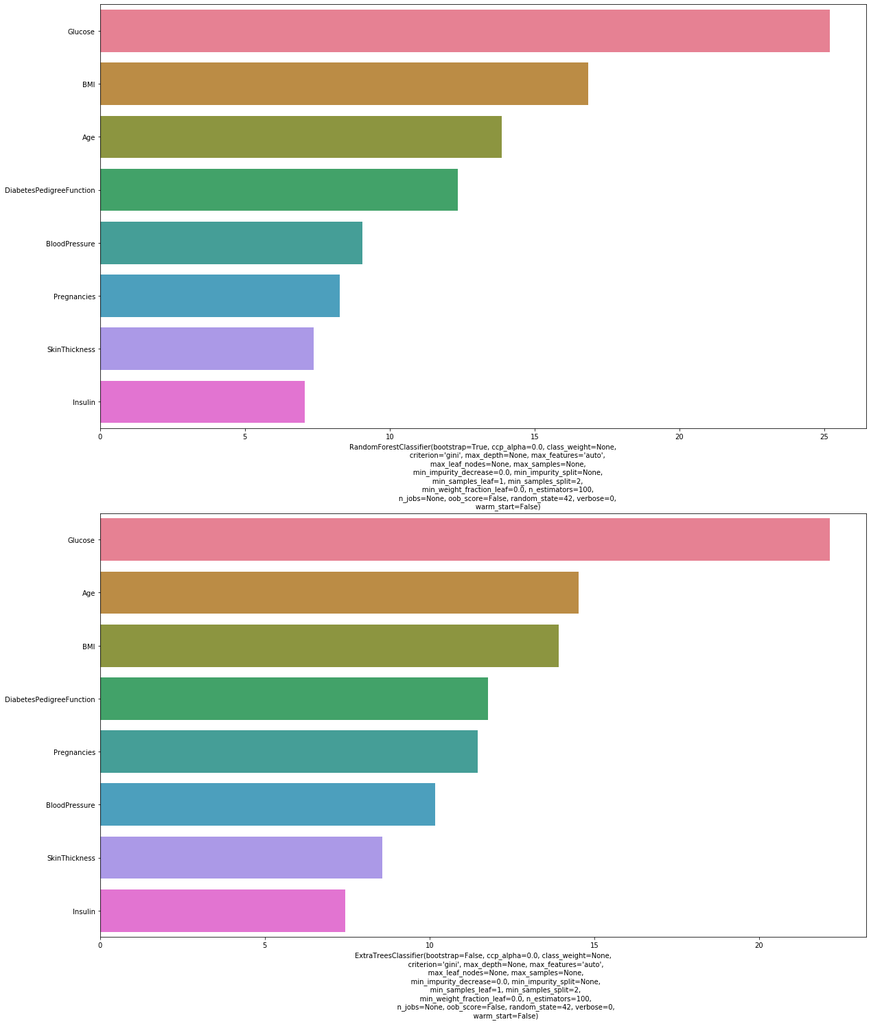

```python
fig = plt.figure(figsize = (20,25))
models_fi = [rfc_fi_test, xtc_fi_test]
for model in models_fi:
    fi = model.feature_importances_
    fi = (fi/np.argmax(fi)) * 100
    order  =  np.argsort(fi)
    fig.add_subplot(2,1, models_fi.index(model) +1)
    sns.barplot(x = fi, y = X_train.columns, order = [X_train.columns[x] for x in order][::-1],palette='husl')
    plt.xlabel(model)
```

Top 4 features of the tree based models are the same. Lets test if it's going to score better than the correlation values.

```python
data_fstree = data[['Glucose', 'BMI', 'Age', 'DiabetesPedigreeFunction','Outcome']]
scores = ModelScores(data_fstree, '_tree', scores)
```

```
SGD : P = 0.609638, PSTD = 0.130588, R = 0.501852
KNN : P = 0.726401, PSTD = 0.039034, R = 0.559687
GNB : P = 0.770779, PSTD = 0.033352, R = 0.582194
XGB : P = 0.777221, PSTD = 0.050187, R = 0.645157
RFC : P = 0.748565, PSTD = 0.060167, R = 0.597293
DTC : P = 0.706904, PSTD = 0.066975, R = 0.578348
ADA : P = 0.760373, PSTD = 0.041018, R = 0.626638
XTC : P = 0.735526, PSTD = 0.073179, R = 0.570798
GBC : P = 0.764217, PSTD = 0.051668, R = 0.626496
```

```python
scores
```

|  | Accuracy | STD | Recall | Accuracy_fscorr | STD_fscorr | Recall_fscorr | Accuracy_tree | STD_tree | Recall_tree |
| --- | --- | --- | --- | --- | --- | --- | --- | --- | --- |
| SGD | 0.487338 | 0.128128 | 0.811538 | 0.632878 | 0.094972 | 0.237037 | 0.609638 | 0.130588 | 0.501852 |
| KNN | 0.710868 | 0.060392 | 0.518519 | 0.745950 | 0.038441 | 0.582621 | 0.726401 | 0.039034 | 0.559687 |
| GNB | 0.755161 | 0.050206 | 0.608262 | 0.756425 | 0.036908 | 0.589886 | 0.770779 | 0.033352 | 0.582194 |
| XGB | 0.765499 | 0.060417 | 0.622650 | 0.770677 | 0.062837 | 0.626923 | 0.777221 | 0.050187 | 0.645157 |
| RFC | 0.769498 | 0.044480 | 0.600855 | 0.745865 | 0.056876 | 0.581766 | 0.748565 | 0.060167 | 0.597293 |
| DTC | 0.702939 | 0.060909 | 0.574501 | 0.695113 | 0.045949 | 0.551994 | 0.706904 | 0.066975 | 0.578348 |
| ADA | 0.751213 | 0.046420 | 0.585470 | 0.747317 | 0.048405 | 0.570940 | 0.760373 | 0.041018 | 0.626638 |
| XTC | 0.757707 | 0.051041 | 0.577778 | 0.732826 | 0.056752 | 0.555556 | 0.735526 | 0.073179 | 0.570798 |
| GBC | 0.765516 | 0.056298 | 0.608120 | 0.775906 | 0.042706 | 0.649430 | 0.764217 | 0.051668 | 0.626496 |

Tree based model scores went up as expected!

Trying feature engineering:

```python
data_addfeature = data_fstree.copy()
data_addfeature['AgePregRatio'] = data_fscorr['Age']/(data_fscorr['Pregnancies'] + 1) #+1  for zero values
data_addfeature.head()
```

|  | Glucose | BMI | Age | DiabetesPedigreeFunction | Outcome | AgePregRatio |
| --- | --- | --- | --- | --- | --- | --- |
| 0 | 148 | 33.6 | 50 | 0.627 | 1 | 7.142857 |
| 1 | 85 | 26.6 | 31 | 0.351 | 0 | 15.500000 |
| 2 | 183 | 23.3 | 32 | 0.672 | 1 | 3.555556 |
| 3 | 89 | 28.1 | 21 | 0.167 | 0 | 10.500000 |
| 4 | 137 | 43.1 | 33 | 2.288 | 1 | 33.000000 |

```python
scores = ModelScores(data_addfeature, 'af', scores)
```

```
SGD : P = 0.523582, PSTD = 0.146319, R = 0.628775
KNN : P = 0.744651, PSTD = 0.050549, R = 0.563675
GNB : P = 0.766900, PSTD = 0.032231, R = 0.582336
XGB : P = 0.781152, PSTD = 0.049547, R = 0.660114
RFC : P = 0.755092, PSTD = 0.050760, R = 0.600712
DTC : P = 0.699060, PSTD = 0.056831, R = 0.571083
ADA : P = 0.755178, PSTD = 0.040768, R = 0.600855
XTC : P = 0.745899, PSTD = 0.060612, R = 0.574074
GBC : P = 0.749846, PSTD = 0.058390, R = 0.618946
```

```python
scores
```

|  | Accuracy | STD | Recall | Accuracy_fscorr | STD_fscorr | Recall_fscorr | Accuracy_tree | STD_tree | Recall_tree | Accuracyaf | STDaf | Recallaf |
| --- | --- | --- | --- | --- | --- | --- | --- | --- | --- | --- | --- | --- |
| SGD | 0.487338 | 0.128128 | 0.811538 | 0.632878 | 0.094972 | 0.237037 | 0.609638 | 0.130588 | 0.501852 | 0.523582 | 0.146319 | 0.628775 |
| KNN | 0.710868 | 0.060392 | 0.518519 | 0.745950 | 0.038441 | 0.582621 | 0.726401 | 0.039034 | 0.559687 | 0.744651 | 0.050549 | 0.563675 |
| GNB | 0.755161 | 0.050206 | 0.608262 | 0.756425 | 0.036908 | 0.589886 | 0.770779 | 0.033352 | 0.582194 | 0.766900 | 0.032231 | 0.582336 |
| XGB | 0.765499 | 0.060417 | 0.622650 | 0.770677 | 0.062837 | 0.626923 | 0.777221 | 0.050187 | 0.645157 | 0.781152 | 0.049547 | 0.660114 |
| RFC | 0.769498 | 0.044480 | 0.600855 | 0.745865 | 0.056876 | 0.581766 | 0.748565 | 0.060167 | 0.597293 | 0.755092 | 0.050760 | 0.600712 |
| DTC | 0.702939 | 0.060909 | 0.574501 | 0.695113 | 0.045949 | 0.551994 | 0.706904 | 0.066975 | 0.578348 | 0.699060 | 0.056831 | 0.571083 |
| ADA | 0.751213 | 0.046420 | 0.585470 | 0.747317 | 0.048405 | 0.570940 | 0.760373 | 0.041018 | 0.626638 | 0.755178 | 0.040768 | 0.600855 |
| XTC | 0.757707 | 0.051041 | 0.577778 | 0.732826 | 0.056752 | 0.555556 | 0.735526 | 0.073179 | 0.570798 | 0.745899 | 0.060612 | 0.574074 |
| GBC | 0.765516 | 0.056298 | 0.608120 | 0.775906 | 0.042706 | 0.649430 | 0.764217 | 0.051668 | 0.626496 | 0.749846 | 0.058390 | 0.618946 |

Highest score found in this set of data! Lets see some aggregation to help us decide what to use.

```python
#make copy of data:
df_raw = data_addfeature.copy()
```

```python
#sgd is sort of an  outlier  in the  last dataset,  i  will exclude  it  first.
scores[1:].describe()
#best scores.  screw sgd.
```

|  | Accuracy | STD | Recall | Accuracy_fscorr | STD_fscorr | Recall_fscorr | Accuracy_tree | STD_tree | Recall_tree | Accuracyaf | STDaf | Recallaf |
| --- | --- | --- | --- | --- | --- | --- | --- | --- | --- | --- | --- | --- |
| count | 8.000000 | 8.000000 | 8.000000 | 8.000000 | 8.000000 | 8.000000 | 8.000000 | 8.000000 | 8.000000 | 8.000000 | 8.000000 | 8.000000 |
| mean | 0.747300 | 0.053770 | 0.587019 | 0.746260 | 0.048609 | 0.588640 | 0.748748 | 0.051948 | 0.598326 | 0.749722 | 0.049961 | 0.596474 |
| std | 0.025736 | 0.006610 | 0.032281 | 0.025004 | 0.009406 | 0.033799 | 0.024189 | 0.014037 | 0.030937 | 0.023750 | 0.009500 | 0.031655 |
| min | 0.702939 | 0.044480 | 0.518519 | 0.695113 | 0.036908 | 0.551994 | 0.706904 | 0.033352 | 0.559687 | 0.699060 | 0.032231 | 0.563675 |
| 25% | 0.741127 | 0.049260 | 0.576959 | 0.742605 | 0.041640 | 0.567094 | 0.733245 | 0.040522 | 0.576460 | 0.745587 | 0.047352 | 0.573326 |
| 50% | 0.756434 | 0.053669 | 0.593162 | 0.746634 | 0.047177 | 0.582194 | 0.754469 | 0.050927 | 0.589744 | 0.752469 | 0.050654 | 0.591524 |
| 75% | 0.765503 | 0.060399 | 0.608155 | 0.759988 | 0.056783 | 0.599145 | 0.765858 | 0.061869 | 0.626531 | 0.758108 | 0.057221 | 0.605377 |
| max | 0.769498 | 0.060909 | 0.622650 | 0.775906 | 0.062837 | 0.649430 | 0.777221 | 0.073179 | 0.645157 | 0.781152 | 0.060612 | 0.660114 |

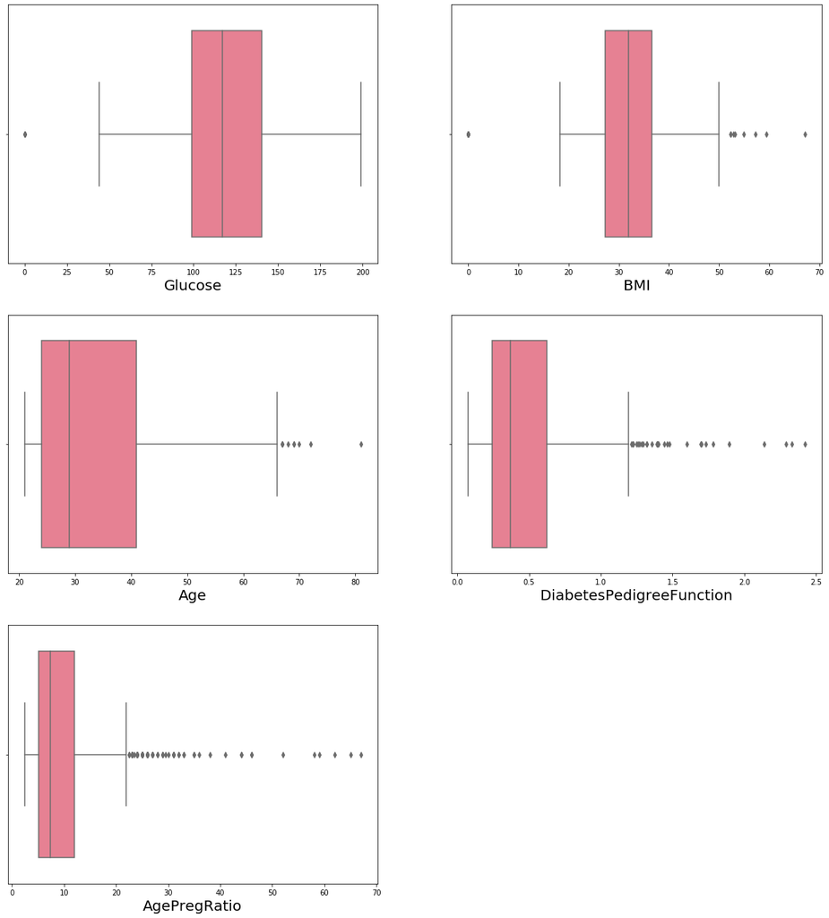

```python
#check outliers  with boxplots
fig = plt.figure(figsize = (20,30))
column_list = list(data_addfeature.drop(columns = 'Outcome').columns)
for column in column_list:
    fig.add_subplot(4,2, column_list.index(column) +1)
    sns.boxplot(data_addfeature[column], palette='husl')
    plt.xlabel(column, fontsize = 20)
```

Let's play with outliers and see how removing them will affect model performance.

```python
def RemoveOutlier(data, column):
    Q1 = data[column].quantile(0.25)
    Q3 = data[column].quantile(0.75)
    IQR = Q3 - Q1    #IQR is interquartile range.

    filter = (data[column] >= Q1 - 1.5 * IQR) & (data[column] <= Q3 + 1.5 *IQR)
    return data[filter]
```

```python
df_glucoseclean = RemoveOutlier(df_raw,'Glucose')
```

```python
print('Lost %i outliers, new length of data: %i' % ((len(df_raw)-len(df_glucoseclean), len(df_glucoseclean))))
```

```
Lost 5 outliers, new length of data: 763
```

```python
scores = ModelScores(df_glucoseclean, '_gclean', scores)
```

```
SGD : P = 0.589798, PSTD = 0.115524, R = 0.451140
KNN : P = 0.750820, PSTD = 0.052703, R = 0.590028
GNB : P = 0.775854, PSTD = 0.043935, R = 0.598433
XGB : P = 0.757399, PSTD = 0.051560, R = 0.609687
RFC : P = 0.754870, PSTD = 0.027331, R = 0.594729
DTC : P = 0.703845, PSTD = 0.027096, R = 0.591026
ADA : P = 0.753435, PSTD = 0.044716, R = 0.601852
XTC : P = 0.758852, PSTD = 0.034263, R = 0.594444
GBC : P = 0.748223, PSTD = 0.045365, R = 0.601567
```

```python
scores
```

|  | Accuracy | STD | Recall | Accuracy_fscorr | STD_fscorr | Recall_fscorr | Accuracy_tree | STD_tree | Recall_tree | Accuracyaf | STDaf | Recallaf | Accuracy_gclean | STD_gclean | Recall_gclean |
| --- | --- | --- | --- | --- | --- | --- | --- | --- | --- | --- | --- | --- | --- | --- | --- |
| SGD | 0.487338 | 0.128128 | 0.811538 | 0.632878 | 0.094972 | 0.237037 | 0.609638 | 0.130588 | 0.501852 | 0.523582 | 0.146319 | 0.628775 | 0.589798 | 0.115524 | 0.451140 |
| KNN | 0.710868 | 0.060392 | 0.518519 | 0.745950 | 0.038441 | 0.582621 | 0.726401 | 0.039034 | 0.559687 | 0.744651 | 0.050549 | 0.563675 | 0.750820 | 0.052703 | 0.590028 |
| GNB | 0.755161 | 0.050206 | 0.608262 | 0.756425 | 0.036908 | 0.589886 | 0.770779 | 0.033352 | 0.582194 | 0.766900 | 0.032231 | 0.582336 | 0.775854 | 0.043935 | 0.598433 |
| XGB | 0.765499 | 0.060417 | 0.622650 | 0.770677 | 0.062837 | 0.626923 | 0.777221 | 0.050187 | 0.645157 | 0.781152 | 0.049547 | 0.660114 | 0.757399 | 0.051560 | 0.609687 |
| RFC | 0.769498 | 0.044480 | 0.600855 | 0.745865 | 0.056876 | 0.581766 | 0.748565 | 0.060167 | 0.597293 | 0.755092 | 0.050760 | 0.600712 | 0.754870 | 0.027331 | 0.594729 |
| DTC | 0.702939 | 0.060909 | 0.574501 | 0.695113 | 0.045949 | 0.551994 | 0.706904 | 0.066975 | 0.578348 | 0.699060 | 0.056831 | 0.571083 | 0.703845 | 0.027096 | 0.591026 |
| ADA | 0.751213 | 0.046420 | 0.585470 | 0.747317 | 0.048405 | 0.570940 | 0.760373 | 0.041018 | 0.626638 | 0.755178 | 0.040768 | 0.600855 | 0.753435 | 0.044716 | 0.601852 |
| XTC | 0.757707 | 0.051041 | 0.577778 | 0.732826 | 0.056752 | 0.555556 | 0.735526 | 0.073179 | 0.570798 | 0.745899 | 0.060612 | 0.574074 | 0.758852 | 0.034263 | 0.594444 |
| GBC | 0.765516 | 0.056298 | 0.608120 | 0.775906 | 0.042706 | 0.649430 | 0.764217 | 0.051668 | 0.626496 | 0.749846 | 0.058390 | 0.618946 | 0.748223 | 0.045365 | 0.601567 |

Slightly better scores, lets try imputing 0 values of BMI with the mean.

```python
df_bmi_impute  =  df_glucoseclean.copy()
df_bmi_impute['BMI'] = df_bmi_impute['BMI'].apply(lambda x: stats.trim_mean(df_bmi_impute['BMI'], 0.05) if x == 0 else x)
```

```python
scores = ModelScores(df_bmi_impute, '_bmiImp', scores)
```

```
SGD : P = 0.574077, PSTD = 0.137106, R = 0.349288
KNN : P = 0.753452, PSTD = 0.051263, R = 0.597721
GNB : P = 0.782433, PSTD = 0.047495, R = 0.616952
XGB : P = 0.758749, PSTD = 0.045660, R = 0.624501
RFC : P = 0.745677, PSTD = 0.039015, R = 0.601994
DTC : P = 0.676299, PSTD = 0.034047, R = 0.575926
ADA : P = 0.744275, PSTD = 0.052013, R = 0.586895
XTC : P = 0.753589, PSTD = 0.028063, R = 0.598575
GBC : P = 0.750940, PSTD = 0.050024, R = 0.613390
```

```python
scores[1:].describe()
```

|  | Accuracy | STD | Recall | Accuracy_fscorr | STD_fscorr | Recall_fscorr | Accuracy_tree | STD_tree | Recall_tree | Accuracyaf | STDaf | Recallaf | Accuracy_gclean | STD_gclean | Recall_gclean | Accuracy_bmiImp | STD_bmiImp | Recall_bmiImp |
| --- | --- | --- | --- | --- | --- | --- | --- | --- | --- | --- | --- | --- | --- | --- | --- | --- | --- | --- |
| count | 8.000000 | 8.000000 | 8.000000 | 8.000000 | 8.000000 | 8.000000 | 8.000000 | 8.000000 | 8.000000 | 8.000000 | 8.000000 | 8.000000 | 8.000000 | 8.000000 | 8.000000 | 8.000000 | 8.000000 | 8.000000 |
| mean | 0.747300 | 0.053770 | 0.587019 | 0.746260 | 0.048609 | 0.588640 | 0.748748 | 0.051948 | 0.598326 | 0.749722 | 0.049961 | 0.596474 | 0.750412 | 0.040871 | 0.597721 | 0.745677 | 0.043448 | 0.601994 |
| std | 0.025736 | 0.006610 | 0.032281 | 0.025004 | 0.009406 | 0.033799 | 0.024189 | 0.014037 | 0.030937 | 0.023750 | 0.009500 | 0.031655 | 0.020598 | 0.010109 | 0.006538 | 0.030444 | 0.008813 | 0.016025 |
| min | 0.702939 | 0.044480 | 0.518519 | 0.695113 | 0.036908 | 0.551994 | 0.706904 | 0.033352 | 0.559687 | 0.699060 | 0.032231 | 0.563675 | 0.703845 | 0.027096 | 0.590028 | 0.676299 | 0.028063 | 0.575926 |
| 25% | 0.741127 | 0.049260 | 0.576959 | 0.742605 | 0.041640 | 0.567094 | 0.733245 | 0.040522 | 0.576460 | 0.745587 | 0.047352 | 0.573326 | 0.750171 | 0.032530 | 0.593590 | 0.745326 | 0.037773 | 0.595014 |
| 50% | 0.756434 | 0.053669 | 0.593162 | 0.746634 | 0.047177 | 0.582194 | 0.754469 | 0.050927 | 0.589744 | 0.752469 | 0.050654 | 0.591524 | 0.754152 | 0.044326 | 0.596581 | 0.752196 | 0.046578 | 0.600285 |
| 75% | 0.765503 | 0.060399 | 0.608155 | 0.759988 | 0.056783 | 0.599145 | 0.765858 | 0.061869 | 0.626531 | 0.758108 | 0.057221 | 0.605377 | 0.757762 | 0.046914 | 0.601638 | 0.754879 | 0.050334 | 0.614281 |
| max | 0.769498 | 0.060909 | 0.622650 | 0.775906 | 0.062837 | 0.649430 | 0.777221 | 0.073179 | 0.645157 | 0.781152 | 0.060612 | 0.660114 | 0.775854 | 0.052703 | 0.609687 | 0.782433 | 0.052013 | 0.624501 |

```python
#removeoutliers  bmi
df_bmi_clean = RemoveOutlier(df_bmi_impute, 'BMI')
```

```python
print('Lost %i outliers, new length of data: %i' % ((len(df_glucoseclean)-len(df_bmi_clean), len(df_bmi_clean))))
```

```
Lost 8 outliers, new length of data: 755
```

```python
scores = ModelScores(df_bmi_clean, '_bmiclean',scores)
```

```
SGD : P = 0.541561, PSTD = 0.171628, R = 0.673077
KNN : P = 0.751123, PSTD = 0.038336, R = 0.573077
GNB : P = 0.774930, PSTD = 0.028757, R = 0.588462
XGB : P = 0.769579, PSTD = 0.019184, R = 0.634615
RFC : P = 0.756404, PSTD = 0.033175, R = 0.611538
DTC : P = 0.718105, PSTD = 0.048508, R = 0.611538
ADA : P = 0.765702, PSTD = 0.032430, R = 0.615385
XTC : P = 0.760404, PSTD = 0.031624, R = 0.584615
GBC : P = 0.749737, PSTD = 0.019088, R = 0.584615
```

```python
scores
```

|  | Accuracy | STD | Recall | Accuracy_fscorr | STD_fscorr | Recall_fscorr | Accuracy_tree | STD_tree | Recall_tree | Accuracyaf | ... | Recallaf | Accuracy_gclean | STD_gclean | Recall_gclean | Accuracy_bmiImp | STD_bmiImp | Recall_bmiImp | Accuracy_bmiclean | STD_bmiclean | Recall_bmiclean |
| --- | --- | --- | --- | --- | --- | --- | --- | --- | --- | --- | --- | --- | --- | --- | --- | --- | --- | --- | --- | --- | --- |
| SGD | 0.487338 | 0.128128 | 0.811538 | 0.632878 | 0.094972 | 0.237037 | 0.609638 | 0.130588 | 0.501852 | 0.523582 | ... | 0.628775 | 0.589798 | 0.115524 | 0.451140 | 0.574077 | 0.137106 | 0.349288 | 0.541561 | 0.171628 | 0.673077 |
| KNN | 0.710868 | 0.060392 | 0.518519 | 0.745950 | 0.038441 | 0.582621 | 0.726401 | 0.039034 | 0.559687 | 0.744651 | ... | 0.563675 | 0.750820 | 0.052703 | 0.590028 | 0.753452 | 0.051263 | 0.597721 | 0.751123 | 0.038336 | 0.573077 |
| GNB | 0.755161 | 0.050206 | 0.608262 | 0.756425 | 0.036908 | 0.589886 | 0.770779 | 0.033352 | 0.582194 | 0.766900 | ... | 0.582336 | 0.775854 | 0.043935 | 0.598433 | 0.782433 | 0.047495 | 0.616952 | 0.774930 | 0.028757 | 0.588462 |
| XGB | 0.765499 | 0.060417 | 0.622650 | 0.770677 | 0.062837 | 0.626923 | 0.777221 | 0.050187 | 0.645157 | 0.781152 | ... | 0.660114 | 0.757399 | 0.051560 | 0.609687 | 0.758749 | 0.045660 | 0.624501 | 0.769579 | 0.019184 | 0.634615 |
| RFC | 0.769498 | 0.044480 | 0.600855 | 0.745865 | 0.056876 | 0.581766 | 0.748565 | 0.060167 | 0.597293 | 0.755092 | ... | 0.600712 | 0.754870 | 0.027331 | 0.594729 | 0.745677 | 0.039015 | 0.601994 | 0.756404 | 0.033175 | 0.611538 |
| DTC | 0.702939 | 0.060909 | 0.574501 | 0.695113 | 0.045949 | 0.551994 | 0.706904 | 0.066975 | 0.578348 | 0.699060 | ... | 0.571083 | 0.703845 | 0.027096 | 0.591026 | 0.676299 | 0.034047 | 0.575926 | 0.718105 | 0.048508 | 0.611538 |
| ADA | 0.751213 | 0.046420 | 0.585470 | 0.747317 | 0.048405 | 0.570940 | 0.760373 | 0.041018 | 0.626638 | 0.755178 | ... | 0.600855 | 0.753435 | 0.044716 | 0.601852 | 0.744275 | 0.052013 | 0.586895 | 0.765702 | 0.032430 | 0.615385 |
| XTC | 0.757707 | 0.051041 | 0.577778 | 0.732826 | 0.056752 | 0.555556 | 0.735526 | 0.073179 | 0.570798 | 0.745899 | ... | 0.574074 | 0.758852 | 0.034263 | 0.594444 | 0.753589 | 0.028063 | 0.598575 | 0.760404 | 0.031624 | 0.584615 |
| GBC | 0.765516 | 0.056298 | 0.608120 | 0.775906 | 0.042706 | 0.649430 | 0.764217 | 0.051668 | 0.626496 | 0.749846 | ... | 0.618946 | 0.748223 | 0.045365 | 0.601567 | 0.750940 | 0.050024 | 0.613390 | 0.749737 | 0.019088 | 0.584615 |

9 rows × 21 columns

```python
#removeoutliers  bmi
df_age_clean = RemoveOutlier(df_bmi_clean, 'Age')
print('Lost %i outliers, new length of data: %i' % ((len(df_bmi_clean)-len(df_age_clean), len(df_age_clean))))
```

```
Lost 9 outliers, new length of data: 746
```

```python
scores = ModelScores(df_age_clean, '_ageclean', scores)
```

```
SGD : P = 0.580162, PSTD = 0.148196, R = 0.359538
KNN : P = 0.747982, PSTD = 0.038769, R = 0.566000
GNB : P = 0.772162, PSTD = 0.038147, R = 0.600615
XGB : P = 0.777532, PSTD = 0.057689, R = 0.655231
RFC : P = 0.765423, PSTD = 0.050953, R = 0.624000
DTC : P = 0.689099, PSTD = 0.067621, R = 0.566000
ADA : P = 0.765387, PSTD = 0.041904, R = 0.604308
XTC : P = 0.760090, PSTD = 0.052729, R = 0.585077
GBC : P = 0.772126, PSTD = 0.049137, R = 0.623846
```

```python
scores.describe()
```

|  | Accuracy | STD | Recall | Accuracy_fscorr | STD_fscorr | Recall_fscorr | Accuracy_tree | STD_tree | Recall_tree | Accuracyaf | ... | Recall_gclean | Accuracy_bmiImp | STD_bmiImp | Recall_bmiImp | Accuracy_bmiclean | STD_bmiclean | Recall_bmiclean | Accuracy_ageclean | STD_ageclean | Recall_ageclean |
| --- | --- | --- | --- | --- | --- | --- | --- | --- | --- | --- | --- | --- | --- | --- | --- | --- | --- | --- | --- | --- | --- |
| count | 9.000000 | 9.000000 | 9.000000 | 9.000000 | 9.000000 | 9.000000 | 9.000000 | 9.000000 | 9.000000 | 9.000000 | ... | 9.000000 | 9.000000 | 9.000000 | 9.000000 | 9.000000 | 9.000000 | 9.000000 | 9.000000 | 9.000000 | 9.000000 |
| mean | 0.718415 | 0.062032 | 0.611966 | 0.733662 | 0.053761 | 0.549573 | 0.733292 | 0.060685 | 0.587607 | 0.724596 | ... | 0.581434 | 0.726610 | 0.053854 | 0.573916 | 0.731949 | 0.046970 | 0.608547 | 0.736663 | 0.060572 | 0.576068 |
| std | 0.089936 | 0.025545 | 0.080702 | 0.044446 | 0.017783 | 0.121390 | 0.051596 | 0.029318 | 0.043262 | 0.078586 | ... | 0.049242 | 0.063897 | 0.032289 | 0.085559 | 0.073258 | 0.047612 | 0.031055 | 0.064490 | 0.034182 | 0.086180 |
| min | 0.487338 | 0.044480 | 0.518519 | 0.632878 | 0.036908 | 0.237037 | 0.609638 | 0.033352 | 0.501852 | 0.523582 | ... | 0.451140 | 0.574077 | 0.028063 | 0.349288 | 0.541561 | 0.019088 | 0.573077 | 0.580162 | 0.038147 | 0.359538 |
| 25% | 0.710868 | 0.050206 | 0.577778 | 0.732826 | 0.042706 | 0.555556 | 0.726401 | 0.041018 | 0.570798 | 0.744651 | ... | 0.591026 | 0.744275 | 0.039015 | 0.586895 | 0.749737 | 0.028757 | 0.584615 | 0.747982 | 0.041904 | 0.566000 |
| 50% | 0.755161 | 0.056298 | 0.600855 | 0.745950 | 0.048405 | 0.581766 | 0.748565 | 0.051668 | 0.582194 | 0.749846 | ... | 0.594729 | 0.750940 | 0.047495 | 0.598575 | 0.756404 | 0.032430 | 0.611538 | 0.765387 | 0.050953 | 0.600615 |
| 75% | 0.765499 | 0.060417 | 0.608262 | 0.756425 | 0.056876 | 0.589886 | 0.764217 | 0.066975 | 0.626496 | 0.755178 | ... | 0.601567 | 0.753589 | 0.051263 | 0.613390 | 0.765702 | 0.038336 | 0.615385 | 0.772126 | 0.057689 | 0.623846 |
| max | 0.769498 | 0.128128 | 0.811538 | 0.775906 | 0.094972 | 0.649430 | 0.777221 | 0.130588 | 0.645157 | 0.781152 | ... | 0.609687 | 0.782433 | 0.137106 | 0.624501 | 0.774930 | 0.171628 | 0.673077 | 0.777532 | 0.148196 | 0.655231 |

8 rows × 24 columns

```python
df_dbp_clean = RemoveOutlier(df_age_clean, 'DiabetesPedigreeFunction')
print('Lost %i outliers, new length of data: %i' % ((len(df_age_clean)-len(df_dbp_clean), len(df_dbp_clean))))
```

```
Lost 28 outliers, new length of data: 718
```

```python
scores = ModelScores(df_dbp_clean, '_dbpclean', scores)
```

```
SGD : P = 0.652876, PSTD = 0.086836, R = 0.170833
KNN : P = 0.764613, PSTD = 0.044171, R = 0.608667
GNB : P = 0.778541, PSTD = 0.042031, R = 0.591167
XGB : P = 0.761796, PSTD = 0.043902, R = 0.604500
RFC : P = 0.757629, PSTD = 0.048833, R = 0.566833
DTC : P = 0.682512, PSTD = 0.057200, R = 0.507667
ADA : P = 0.757629, PSTD = 0.040573, R = 0.588000
XTC : P = 0.767390, PSTD = 0.049439, R = 0.571333
GBC : P = 0.766002, PSTD = 0.037810, R = 0.600167
```

```python
scores.describe()
```

|  | Accuracy | STD | Recall | Accuracy_fscorr | STD_fscorr | Recall_fscorr | Accuracy_tree | STD_tree | Recall_tree | Accuracyaf | ... | Recall_bmiImp | Accuracy_bmiclean | STD_bmiclean | Recall_bmiclean | Accuracy_ageclean | STD_ageclean | Recall_ageclean | Accuracy_dbpclean | STD_dbpclean | Recall_dbpclean |
| --- | --- | --- | --- | --- | --- | --- | --- | --- | --- | --- | --- | --- | --- | --- | --- | --- | --- | --- | --- | --- | --- |
| count | 9.000000 | 9.000000 | 9.000000 | 9.000000 | 9.000000 | 9.000000 | 9.000000 | 9.000000 | 9.000000 | 9.000000 | ... | 9.000000 | 9.000000 | 9.000000 | 9.000000 | 9.000000 | 9.000000 | 9.000000 | 9.000000 | 9.000000 | 9.000000 |
| mean | 0.718415 | 0.062032 | 0.611966 | 0.733662 | 0.053761 | 0.549573 | 0.733292 | 0.060685 | 0.587607 | 0.724596 | ... | 0.573916 | 0.731949 | 0.046970 | 0.608547 | 0.736663 | 0.060572 | 0.576068 | 0.743221 | 0.050088 | 0.534352 |
| std | 0.089936 | 0.025545 | 0.080702 | 0.044446 | 0.017783 | 0.121390 | 0.051596 | 0.029318 | 0.043262 | 0.078586 | ... | 0.085559 | 0.073258 | 0.047612 | 0.031055 | 0.064490 | 0.034182 | 0.086180 | 0.043898 | 0.014927 | 0.139715 |
| min | 0.487338 | 0.044480 | 0.518519 | 0.632878 | 0.036908 | 0.237037 | 0.609638 | 0.033352 | 0.501852 | 0.523582 | ... | 0.349288 | 0.541561 | 0.019088 | 0.573077 | 0.580162 | 0.038147 | 0.359538 | 0.652876 | 0.037810 | 0.170833 |
| 25% | 0.710868 | 0.050206 | 0.577778 | 0.732826 | 0.042706 | 0.555556 | 0.726401 | 0.041018 | 0.570798 | 0.744651 | ... | 0.586895 | 0.749737 | 0.028757 | 0.584615 | 0.747982 | 0.041904 | 0.566000 | 0.757629 | 0.042031 | 0.566833 |
| 50% | 0.755161 | 0.056298 | 0.600855 | 0.745950 | 0.048405 | 0.581766 | 0.748565 | 0.051668 | 0.582194 | 0.749846 | ... | 0.598575 | 0.756404 | 0.032430 | 0.611538 | 0.765387 | 0.050953 | 0.600615 | 0.761796 | 0.044171 | 0.588000 |
| 75% | 0.765499 | 0.060417 | 0.608262 | 0.756425 | 0.056876 | 0.589886 | 0.764217 | 0.066975 | 0.626496 | 0.755178 | ... | 0.613390 | 0.765702 | 0.038336 | 0.615385 | 0.772126 | 0.057689 | 0.623846 | 0.766002 | 0.049439 | 0.600167 |
| max | 0.769498 | 0.128128 | 0.811538 | 0.775906 | 0.094972 | 0.649430 | 0.777221 | 0.130588 | 0.645157 | 0.781152 | ... | 0.624501 | 0.774930 | 0.171628 | 0.673077 | 0.777532 | 0.148196 | 0.655231 | 0.778541 | 0.086836 | 0.608667 |

8 rows × 27 columns

```python
df_apr_clean = RemoveOutlier(df_dbp_clean, 'AgePregRatio')
print('Lost %i outliers, new length of data: %i' % ((len(df_dbp_clean)-len(df_apr_clean), len(df_apr_clean))))
```

```
Lost 72 outliers, new length of data: 646
```

```python
scores = ModelScores(df_apr_clean, '_aprclean', scores)
```

```
SGD : P = 0.631178, PSTD = 0.131169, R = 0.639610
KNN : P = 0.773942, PSTD = 0.045566, R = 0.595022
GNB : P = 0.783197, PSTD = 0.041328, R = 0.595022
XGB : P = 0.760024, PSTD = 0.037440, R = 0.561688
RFC : P = 0.770889, PSTD = 0.046928, R = 0.604329
DTC : P = 0.724183, PSTD = 0.066783, R = 0.594589
ADA : P = 0.752260, PSTD = 0.048001, R = 0.570779
XTC : P = 0.767837, PSTD = 0.047731, R = 0.571645
GBC : P = 0.764760, PSTD = 0.047306, R = 0.576190
```

```python
scores.describe()
```

|  | Accuracy | STD | Recall | Accuracy_fscorr | STD_fscorr | Recall_fscorr | Accuracy_tree | STD_tree | Recall_tree | Accuracyaf | ... | Recall_bmiclean | Accuracy_ageclean | STD_ageclean | Recall_ageclean | Accuracy_dbpclean | STD_dbpclean | Recall_dbpclean | Accuracy_aprclean | STD_aprclean | Recall_aprclean |
| --- | --- | --- | --- | --- | --- | --- | --- | --- | --- | --- | --- | --- | --- | --- | --- | --- | --- | --- | --- | --- | --- |
| count | 9.000000 | 9.000000 | 9.000000 | 9.000000 | 9.000000 | 9.000000 | 9.000000 | 9.000000 | 9.000000 | 9.000000 | ... | 9.000000 | 9.000000 | 9.000000 | 9.000000 | 9.000000 | 9.000000 | 9.000000 | 9.000000 | 9.000000 | 9.000000 |
| mean | 0.718415 | 0.062032 | 0.611966 | 0.733662 | 0.053761 | 0.549573 | 0.733292 | 0.060685 | 0.587607 | 0.724596 | ... | 0.608547 | 0.736663 | 0.060572 | 0.576068 | 0.743221 | 0.050088 | 0.534352 | 0.747585 | 0.056917 | 0.589875 |
| std | 0.089936 | 0.025545 | 0.080702 | 0.044446 | 0.017783 | 0.121390 | 0.051596 | 0.029318 | 0.043262 | 0.078586 | ... | 0.031055 | 0.064490 | 0.034182 | 0.086180 | 0.043898 | 0.014927 | 0.139715 | 0.046752 | 0.028978 | 0.023549 |
| min | 0.487338 | 0.044480 | 0.518519 | 0.632878 | 0.036908 | 0.237037 | 0.609638 | 0.033352 | 0.501852 | 0.523582 | ... | 0.573077 | 0.580162 | 0.038147 | 0.359538 | 0.652876 | 0.037810 | 0.170833 | 0.631178 | 0.037440 | 0.561688 |
| 25% | 0.710868 | 0.050206 | 0.577778 | 0.732826 | 0.042706 | 0.555556 | 0.726401 | 0.041018 | 0.570798 | 0.744651 | ... | 0.584615 | 0.747982 | 0.041904 | 0.566000 | 0.757629 | 0.042031 | 0.566833 | 0.752260 | 0.045566 | 0.571645 |
| 50% | 0.755161 | 0.056298 | 0.600855 | 0.745950 | 0.048405 | 0.581766 | 0.748565 | 0.051668 | 0.582194 | 0.749846 | ... | 0.611538 | 0.765387 | 0.050953 | 0.600615 | 0.761796 | 0.044171 | 0.588000 | 0.764760 | 0.047306 | 0.594589 |
| 75% | 0.765499 | 0.060417 | 0.608262 | 0.756425 | 0.056876 | 0.589886 | 0.764217 | 0.066975 | 0.626496 | 0.755178 | ... | 0.615385 | 0.772126 | 0.057689 | 0.623846 | 0.766002 | 0.049439 | 0.600167 | 0.770889 | 0.048001 | 0.595022 |
| max | 0.769498 | 0.128128 | 0.811538 | 0.775906 | 0.094972 | 0.649430 | 0.777221 | 0.130588 | 0.645157 | 0.781152 | ... | 0.673077 | 0.777532 | 0.148196 | 0.655231 | 0.778541 | 0.086836 | 0.608667 | 0.783197 | 0.131169 | 0.639610 |

8 rows × 30 columns

Visualization of performance per dataset modification:

```python
def GraphScores(data, agg):
    scores_aggregation = pd.DataFrame(data.describe())
    acc_cols = scores_aggregation.columns[scores_aggregation.columns.str.contains('Accuracy', na=False)]
    index_pivot = list(scores_aggregation.index)
    acc_table = pd.DataFrame(scores_aggregation.T,  index =  acc_cols)
    sns.set_style("darkgrid")
    plt.xticks(rotation = 90)
    return sns.lineplot(x  = list(acc_table.index),  y=acc_table[agg],  sort = False)
```

[figure not shown]

```python
plt.figure(figsize= (15,15))
GraphScores(scores, 'mean')
```

We have major performance dips when adding a feature and imputing bmi, lets see our performance without them.

notes:

- Without adding a feature, we will not have the _aprclean dataset which gave us the final increase in accuracy.

Our mean accuracy improved throughout our models. Time to scale it! notes: - I experimented configurations and the process above come out on top. Removing the downtrends (bmi imputation, tree based feature selection, adding features) gave worse results. I dont wanna clutter my notebook to show all the configurations XD

```python
df_unscaled = df_apr_clean.copy()
y_final = df_unscaled.Outcome
```

```python
def ModelScoresScaled(X, y,  suffix, scores):
    models =[['SGD', SGDClassifier(random_state= 42)],
             ['KNN', KNeighborsClassifier()],
             ['GNB', GaussianNB()],
             ['XGB', XGBClassifier(random_state= 42)],
             ['RFC', RandomForestClassifier(random_state= 42)],
             ['DTC', DecisionTreeClassifier(random_state= 42)],
             ['ADA', AdaBoostClassifier(random_state= 42)],
             ['XTC', ExtraTreesClassifier(random_state= 42)],
             ['GBC', GradientBoostingClassifier(random_state= 42)]]
    Model = [x[0] for x in models]
    table = {'Accuracy'+suffix :[],
             'STD'+suffix : [],
             'Recall'+suffix : []}
    for name, model in models:
        kfold = StratifiedKFold(n_splits=10, random_state=42, shuffle = True)
        accuracy = cross_val_score(model, X, y, cv = kfold).mean()
        accuracyStd = cross_val_score(model, X, y, cv = kfold).std()
        recall = cross_val_score(model, X, y, cv = kfold, scoring = 'recall').mean()
        table['Accuracy'+suffix].append(accuracy)
        table['STD'+suffix].append(accuracyStd)
        table['Recall'+suffix].append(recall)
        msg = '%s : P = %f, PSTD = %f, R = %f' % (name, accuracy, accuracyStd, recall)
        print(msg)
    df = pd.DataFrame(table, index = Model)
    scores = scores.join(df)
    return scores
```

```python
X_ss  = StandardScaler().fit_transform(df_unscaled[['Glucose', 'BMI', 'Age', 'DiabetesPedigreeFunction']])
```

```python
scores = ModelScoresScaled(X_ss, y_final,'_sscaler', scores)
```

```
SGD : P = 0.736755, PSTD = 0.028550, R = 0.474892
KNN : P = 0.764591, PSTD = 0.047445, R = 0.594805
GNB : P = 0.789375, PSTD = 0.047467, R = 0.608874
XGB : P = 0.761562, PSTD = 0.039973, R = 0.599134
RFC : P = 0.764639, PSTD = 0.036238, R = 0.590043
DTC : P = 0.716490, PSTD = 0.056125, R = 0.562121
ADA : P = 0.755361, PSTD = 0.046476, R = 0.571212
XTC : P = 0.780168, PSTD = 0.044246, R = 0.590476
GBC : P = 0.760072, PSTD = 0.034658, R = 0.589827
```

```python
scores
```

|  | Accuracy | STD | Recall | Accuracy_fscorr | STD_fscorr | Recall_fscorr | Accuracy_tree | STD_tree | Recall_tree | Accuracyaf | ... | Recall_ageclean | Accuracy_dbpclean | STD_dbpclean | Recall_dbpclean | Accuracy_aprclean | STD_aprclean | Recall_aprclean | Accuracy_sscaler | STD_sscaler | Recall_sscaler |
| --- | --- | --- | --- | --- | --- | --- | --- | --- | --- | --- | --- | --- | --- | --- | --- | --- | --- | --- | --- | --- | --- |
| SGD | 0.487338 | 0.128128 | 0.811538 | 0.632878 | 0.094972 | 0.237037 | 0.609638 | 0.130588 | 0.501852 | 0.523582 | ... | 0.359538 | 0.652876 | 0.086836 | 0.170833 | 0.631178 | 0.131169 | 0.639610 | 0.736755 | 0.028550 | 0.474892 |
| KNN | 0.710868 | 0.060392 | 0.518519 | 0.745950 | 0.038441 | 0.582621 | 0.726401 | 0.039034 | 0.559687 | 0.744651 | ... | 0.566000 | 0.764613 | 0.044171 | 0.608667 | 0.773942 | 0.045566 | 0.595022 | 0.764591 | 0.047445 | 0.594805 |
| GNB | 0.755161 | 0.050206 | 0.608262 | 0.756425 | 0.036908 | 0.589886 | 0.770779 | 0.033352 | 0.582194 | 0.766900 | ... | 0.600615 | 0.778541 | 0.042031 | 0.591167 | 0.783197 | 0.041328 | 0.595022 | 0.789375 | 0.047467 | 0.608874 |
| XGB | 0.765499 | 0.060417 | 0.622650 | 0.770677 | 0.062837 | 0.626923 | 0.777221 | 0.050187 | 0.645157 | 0.781152 | ... | 0.655231 | 0.761796 | 0.043902 | 0.604500 | 0.760024 | 0.037440 | 0.561688 | 0.761562 | 0.039973 | 0.599134 |
| RFC | 0.769498 | 0.044480 | 0.600855 | 0.745865 | 0.056876 | 0.581766 | 0.748565 | 0.060167 | 0.597293 | 0.755092 | ... | 0.624000 | 0.757629 | 0.048833 | 0.566833 | 0.770889 | 0.046928 | 0.604329 | 0.764639 | 0.036238 | 0.590043 |
| DTC | 0.702939 | 0.060909 | 0.574501 | 0.695113 | 0.045949 | 0.551994 | 0.706904 | 0.066975 | 0.578348 | 0.699060 | ... | 0.566000 | 0.682512 | 0.057200 | 0.507667 | 0.724183 | 0.066783 | 0.594589 | 0.716490 | 0.056125 | 0.562121 |
| ADA | 0.751213 | 0.046420 | 0.585470 | 0.747317 | 0.048405 | 0.570940 | 0.760373 | 0.041018 | 0.626638 | 0.755178 | ... | 0.604308 | 0.757629 | 0.040573 | 0.588000 | 0.752260 | 0.048001 | 0.570779 | 0.755361 | 0.046476 | 0.571212 |
| XTC | 0.757707 | 0.051041 | 0.577778 | 0.732826 | 0.056752 | 0.555556 | 0.735526 | 0.073179 | 0.570798 | 0.745899 | ... | 0.585077 | 0.767390 | 0.049439 | 0.571333 | 0.767837 | 0.047731 | 0.571645 | 0.780168 | 0.044246 | 0.590476 |
| GBC | 0.765516 | 0.056298 | 0.608120 | 0.775906 | 0.042706 | 0.649430 | 0.764217 | 0.051668 | 0.626496 | 0.749846 | ... | 0.623846 | 0.766002 | 0.037810 | 0.600167 | 0.764760 | 0.047306 | 0.576190 | 0.760072 | 0.034658 | 0.589827 |

9 rows × 33 columns

```python
X_mm  = MinMaxScaler().fit_transform(df_unscaled[['Glucose', 'BMI', 'Age', 'DiabetesPedigreeFunction']])
```

```python
scores = ModelScoresScaled(X_mm, y_final,'_mmscaler', scores)
```

```
SGD : P = 0.763077, PSTD = 0.044282, R = 0.523810
KNN : P = 0.767692, PSTD = 0.048977, R = 0.589827
GNB : P = 0.789375, PSTD = 0.047467, R = 0.608874
XGB : P = 0.761562, PSTD = 0.039973, R = 0.599134
RFC : P = 0.763101, PSTD = 0.032099, R = 0.585281
DTC : P = 0.718029, PSTD = 0.058551, R = 0.562121
ADA : P = 0.755361, PSTD = 0.046476, R = 0.571212
XTC : P = 0.780168, PSTD = 0.044246, R = 0.590476
GBC : P = 0.760072, PSTD = 0.034658, R = 0.589827
```

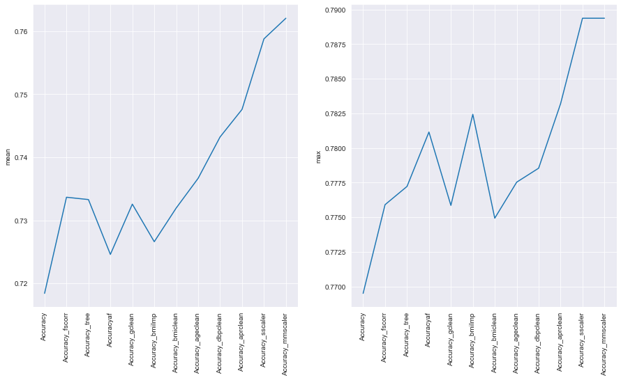

```python
fig =  plt.figure(figsize= (15,8))
fig.add_subplot(1,2,1)
GraphScores(scores, 'mean')
fig.add_subplot(1,2,2)
GraphScores(scores, 'max')
```

# Parameter Tuning

```python
kfold = StratifiedKFold(n_splits=10, random_state=42, shuffle = True)
```

Scale after splitting to avoid overfitting.

```python
X_train, X_test, y_train, y_test = train_test_split(df_unscaled[['Glucose', 'BMI', 'Age', 'DiabetesPedigreeFunction']],
                                                    y_final,
                                                    train_size = 0.8,
                                                    stratify = y_final)
X_train = MinMaxScaler().fit_transform(X_train)
X_test = MinMaxScaler().fit_transform(X_test)
```

```python
#preliminary classifiers without parameter tuning.
SGD = SGDClassifier(random_state= 42)
KNN = KNeighborsClassifier()
GNBfinal = GaussianNB() #no params to tune
XGB = XGBClassifier(random_state= 42)
RFC = RandomForestClassifier(random_state= 42)
DTC = DecisionTreeClassifier(random_state= 42)
ADA = AdaBoostClassifier(random_state= 42)
XTC = ExtraTreesClassifier(random_state= 42)
GBC = GradientBoostingClassifier(random_state= 42)
```

```python
#SGD optimization
params_grid ={'loss': ['log','modified_huber'],
              'penalty': ['l2', 'l1', 'elasticnet'],
              'alpha': [0.009,0.01,0.02,0.03]
              }
optimal_params = GridSearchCV(SGD,
                              param_grid=params_grid,
                              verbose =  2,
                              cv = kfold,
                              n_jobs=-1)
```

```python
best_params = optimal_params.fit(X_train,  y_train)
```

```
Fitting 10 folds for each of 24 candidates, totalling 240 fits
```

```
[Parallel(n_jobs=-1)]: Using backend LokyBackend with 4 concurrent workers.
[Parallel(n_jobs=-1)]: Done  38 tasks      | elapsed:    2.2s
[Parallel(n_jobs=-1)]: Done 240 out of 240 | elapsed:    2.5s finished
```

```python
sgdparams =  best_params.best_params_
sgdparams
```

```
{'alpha': 0.02, 'loss': 'modified_huber', 'penalty': 'l1'}
```

```python
SGDfinal = SGDClassifier(**sgdparams, random_state= 42)
```

```python
cross_val_score(SGDfinal, X_train, y_train, scoring = 'accuracy',  cv = kfold).mean()
```

```
0.7906862745098039
```

```python
#KNN optimization
params_grid ={'n_neighbors' : [1,2,3,4,5,6,7,8,9,10,11,12,13,14,15,16,17,18,19,20]
              }
optimal_params = GridSearchCV(KNN,
                              param_grid=params_grid,
                              verbose =  2,
                              cv = kfold,
                              n_jobs=-1)
```

```python
best_params = optimal_params.fit(X_train,  y_train)
```

```
Fitting 10 folds for each of 20 candidates, totalling 200 fits
```

```
[Parallel(n_jobs=-1)]: Using backend LokyBackend with 4 concurrent workers.
[Parallel(n_jobs=-1)]: Done 136 tasks      | elapsed:    0.2s
[Parallel(n_jobs=-1)]: Done 200 out of 200 | elapsed:    0.3s finished
```

```python
knnparams =  best_params.best_params_
knnparams
```

```
{'n_neighbors': 15}
```

```python
KNNfinal = KNeighborsClassifier(**knnparams)
```

```python
cross_val_score(KNNfinal, X_train, y_train, scoring = 'accuracy', cv =  kfold).mean()
```

```
0.8005656108597285
```

```python
#parameter tuning with  XGB (done)
params_grid ={'max_depth': [3],
              'learning_rate': [0.09,0.1],
              'gamma': [3],
              'reg_lambda': [2],
              'scale_pos_weight': [2],
              'random_state' : [42],
              'subsample' : [0.9,1],
              'colsample_bytree' : [0.5]
              }
```

```python
optimal_params = GridSearchCV(XGB,
                              param_grid=params_grid,
                              verbose =  2,
                              cv = kfold,
                              n_jobs=-1)
```

```python
grid_result = optimal_params.fit(X_train, y_train)
```

```
Fitting 10 folds for each of 4 candidates, totalling 40 fits
```

```
[Parallel(n_jobs=-1)]: Using backend LokyBackend with 4 concurrent workers.
[Parallel(n_jobs=-1)]: Done  40 out of  40 | elapsed:    0.5s finished
```

```python
xgbparams = grid_result.best_params_
xgbparams
```

```
{'colsample_bytree': 0.5,
 'gamma': 3,
 'learning_rate': 0.1,
 'max_depth': 3,
 'random_state': 42,
 'reg_lambda': 2,
 'scale_pos_weight': 2,
 'subsample': 1}
```

```python
XGBfinal = XGBClassifier(**xgbparams)
```

```python
cross_val_score(XGBfinal, X_train, y_train, scoring = 'accuracy', cv = kfold).mean()
```

```
0.7442684766214178
```

```python
#RFC tuning
params_grid ={'max_features': ['auto'],
              'n_estimators': [75],
              'criterion': ['entropy'],
              'min_samples_split': [3]
              }
optimal_params = GridSearchCV(RFC,
                              param_grid=params_grid,
                              verbose =  2,
                              cv = kfold,
                              n_jobs=-1)
```

```python
grid_result = optimal_params.fit(X_train, y_train)
```

```
Fitting 10 folds for each of 1 candidates, totalling 10 fits
```

```
[Parallel(n_jobs=-1)]: Using backend LokyBackend with 4 concurrent workers.
[Parallel(n_jobs=-1)]: Done  10 out of  10 | elapsed:    0.7s finished
```

```python
rfcparams = grid_result.best_params_
rfcparams
```

```
{'criterion': 'entropy',
 'max_features': 'auto',
 'min_samples_split': 3,
 'n_estimators': 75}
```

```python
RFCfinal = RandomForestClassifier(**rfcparams,  random_state  =  42)
```

```python
cross_val_score(RFCfinal, X_train, y_train, scoring = 'accuracy', cv = kfold).mean()
```

```
0.7751131221719456
```

```python
#DTC Tuning
params_grid ={'max_depth': [5,6,'None'],
              'min_samples_leaf': [3],
              'criterion': ['gini', 'entropy'],
              'max_features': [0,1,2,3,4]
              }
optimal_params = GridSearchCV(DTC,
                              param_grid=params_grid,
                              verbose =  2,
                              cv = kfold,
                              n_jobs=-1)
```

```python
grid_result = optimal_params.fit(X_train, y_train)
```

```
Fitting 10 folds for each of 30 candidates, totalling 300 fits
```

```
[Parallel(n_jobs=-1)]: Using backend LokyBackend with 4 concurrent workers.
[Parallel(n_jobs=-1)]: Done 136 tasks      | elapsed:    0.3s
[Parallel(n_jobs=-1)]: Done 300 out of 300 | elapsed:    0.5s finished
```

```python
dtcparams = grid_result.best_params_
dtcparams
```

```
{'criterion': 'gini', 'max_depth': 5, 'max_features': 1, 'min_samples_leaf': 3}
```

```python
DTCfinal = DecisionTreeClassifier(**dtcparams,  random_state  =  42)
```

```python
cross_val_score(DTCfinal, X_train, y_train, scoring = 'accuracy',  cv = kfold).mean()
```

```
0.7674962292609351
```

```python
#ADAboost tuning
params_grid ={'learning_rate' : [.05,.1,.5,1],
              'n_estimators' : [50,100,150,200,250,300]
              }
optimal_params = GridSearchCV(ADA,
                              param_grid=params_grid,
                              verbose =  2,
                              cv = kfold,
                              n_jobs=-1)
```

```python
grid_result = optimal_params.fit(X_train, y_train)
```

```
Fitting 10 folds for each of 24 candidates, totalling 240 fits
```

```
[Parallel(n_jobs=-1)]: Using backend LokyBackend with 4 concurrent workers.
[Parallel(n_jobs=-1)]: Done  58 tasks      | elapsed:    4.8s
[Parallel(n_jobs=-1)]: Done 240 out of 240 | elapsed:   20.9s finished
```

```python
adaparams = grid_result.best_params_
adaparams
```

```
{'learning_rate': 0.05, 'n_estimators': 100}
```

```python
ADAfinal = AdaBoostClassifier(**adaparams,  random_state  =  42)
```

```python
cross_val_score(ADAfinal, X_train, y_train, scoring = 'accuracy',  cv =  kfold).mean()
```

```
0.7888763197586727
```

```python
#XTCboost tuning
params_grid ={'n_estimators': [200],
              'criterion': ['gini'],
              'max_depth': [5],
              'max_features': ['auto'],
              'bootstrap': ['True']
              }
optimal_params = GridSearchCV(XTC,
                              param_grid=params_grid,
                              verbose =  2,
                              cv = kfold,
                              n_jobs=-1)
```

```python
grid_result = optimal_params.fit(X_train, y_train)
```

```
Fitting 10 folds for each of 1 candidates, totalling 10 fits
```

```
[Parallel(n_jobs=-1)]: Using backend LokyBackend with 4 concurrent workers.
[Parallel(n_jobs=-1)]: Done  10 out of  10 | elapsed:    0.9s finished
```

```python
xtcparams = grid_result.best_params_
xtcparams
```

```
{'bootstrap': 'True',
 'criterion': 'gini',
 'max_depth': 5,
 'max_features': 'auto',
 'n_estimators': 200}
```

```python
XTCfinal = ExtraTreesClassifier(**xtcparams,  random_state  =  42)
```

```python
cross_val_score(XTCfinal, X_train, y_train, scoring = 'accuracy', cv =  kfold).mean()
```

```
0.7946078431372549
```

```python
#GBCboost tuning
params_grid ={'learning_rate': [0.01,0.02,0.0075],
              'n_estimators' : [300,350,400,500,600]
              }
optimal_params = GridSearchCV(GBC,
                              param_grid=params_grid,
                              verbose =  2,
                              cv = kfold,
                              n_jobs=-1)
```

```python
grid_result = optimal_params.fit(X_train, y_train)
```

```
Fitting 10 folds for each of 15 candidates, totalling 150 fits
```

```
[Parallel(n_jobs=-1)]: Using backend LokyBackend with 4 concurrent workers.
[Parallel(n_jobs=-1)]: Done  33 tasks      | elapsed:    3.2s
[Parallel(n_jobs=-1)]: Done 150 out of 150 | elapsed:   16.7s finished
```

```python
gbcparams = grid_result.best_params_
gbcparams
```

```
{'learning_rate': 0.0075, 'n_estimators': 500}
```

```python
GBCfinal = GradientBoostingClassifier(**gbcparams,  random_state  =  42)
```

```python
cross_val_score(GBCfinal, X_train, y_train, scoring = 'accuracy',  cv =  kfold).mean()
```

```
0.7791478129713424
```

ENSEMBLING MODELS

```python
kfold = StratifiedKFold(n_splits=10, random_state=42, shuffle = True)
```

```python
#models
final_models = [#('SGDfinal', SGDClassifier(**sgdparams, random_state= 42)),
                ('KNNfinal', KNeighborsClassifier(**knnparams)),
                ('GNBfinal', GaussianNB()),
                ('XGBfinal', XGBClassifier(**xgbparams)),
                ('RFCfinal', RandomForestClassifier(**rfcparams,  random_state  =  42)),
                ('DTCfinal', DecisionTreeClassifier(**dtcparams,  random_state  =  42)),
                ('ADAfinal', AdaBoostClassifier(**adaparams,  random_state  =  42)),
                ('XTCfinal', ExtraTreesClassifier(**xtcparams,  random_state  =  42)),
                ('GBCfinal', GradientBoostingClassifier(**gbcparams,  random_state  =  42))]
final_models
```

```
[('KNNfinal',
  KNeighborsClassifier(algorithm='auto', leaf_size=30, metric='minkowski',
                       metric_params=None, n_jobs=None, n_neighbors=15, p=2,
                       weights='uniform')),
 ('GNBfinal', GaussianNB(priors=None, var_smoothing=1e-09)),
 ('XGBfinal',
  XGBClassifier(base_score=0.5, booster='gbtree', colsample_bylevel=1,
                colsample_bynode=1, colsample_bytree=0.5, gamma=3,
                learning_rate=0.1, max_delta_step=0, max_depth=3,
                min_child_weight=1, missing=None, n_estimators=100, n_jobs=1,
                nthread=None, objective='binary:logistic', random_state=42,
                reg_alpha=0, reg_lambda=2, scale_pos_weight=2, seed=None,
                silent=None, subsample=1, verbosity=1)),
 ('RFCfinal',
  RandomForestClassifier(bootstrap=True, ccp_alpha=0.0, class_weight=None,
                         criterion='entropy', max_depth=None, max_features='auto',
                         max_leaf_nodes=None, max_samples=None,
                         min_impurity_decrease=0.0, min_impurity_split=None,
                         min_samples_leaf=1, min_samples_split=3,
                         min_weight_fraction_leaf=0.0, n_estimators=75,
                         n_jobs=None, oob_score=False, random_state=42, verbose=0,
                         warm_start=False)),
 ('DTCfinal',
  DecisionTreeClassifier(ccp_alpha=0.0, class_weight=None, criterion='gini',
                         max_depth=5, max_features=1, max_leaf_nodes=None,
                         min_impurity_decrease=0.0, min_impurity_split=None,
                         min_samples_leaf=3, min_samples_split=2,
                         min_weight_fraction_leaf=0.0, presort='deprecated',
                         random_state=42, splitter='best')),
 ('ADAfinal',
  AdaBoostClassifier(algorithm='SAMME.R', base_estimator=None, learning_rate=0.05,
                     n_estimators=100, random_state=42)),
 ('XTCfinal',
  ExtraTreesClassifier(bootstrap='True', ccp_alpha=0.0, class_weight=None,
                       criterion='gini', max_depth=5, max_features='auto',
                       max_leaf_nodes=None, max_samples=None,
                       min_impurity_decrease=0.0, min_impurity_split=None,
                       min_samples_leaf=1, min_samples_split=2,
                       min_weight_fraction_leaf=0.0, n_estimators=200,
                       n_jobs=None, oob_score=False, random_state=42, verbose=0,
                       warm_start=False)),
 ('GBCfinal',
  GradientBoostingClassifier(ccp_alpha=0.0, criterion='friedman_mse', init=None,
                             learning_rate=0.0075, loss='deviance', max_depth=3,
                             max_features=None, max_leaf_nodes=None,
                             min_impurity_decrease=0.0, min_impurity_split=None,
                             min_samples_leaf=1, min_samples_split=2,
                             min_weight_fraction_leaf=0.0, n_estimators=500,
                             n_iter_no_change=None, presort='deprecated',
                             random_state=42, subsample=1.0, tol=0.0001,
                             validation_fraction=0.1, verbose=0,
                             warm_start=False))]
```

```python
ensemble = VotingClassifier(final_models)
results = cross_val_score(ensemble, X_train, y_train, scoring =  'accuracy', cv=kfold)
print('Accuracy on train:',results.mean())
ensemble_model = ensemble.fit(X_train,y_train)
pred = ensemble_model.predict(X_test)
print('Accuracy on test:' , (y_test == pred).mean())
```

```
Accuracy on train: 0.7927224736048265
Accuracy on test: 0.7923076923076923
```

```python
#create  dataframe of probabilities
def ModelProbaDF(model_list, xtrain, ytrain, xtest, ytest):
    cols = [x[0]  for  x in  model_list]
    df  =  pd.DataFrame(index = range(len(y_test)))
    for x in model_list:
        x[1].fit(xtrain, ytrain)
        df[x[0]]= x[1].predict_proba(xtest)[:,0]
    return df
```

```python
corr_table = ModelProbaDF(final_models,X_train,y_train,X_test,y_test)
```

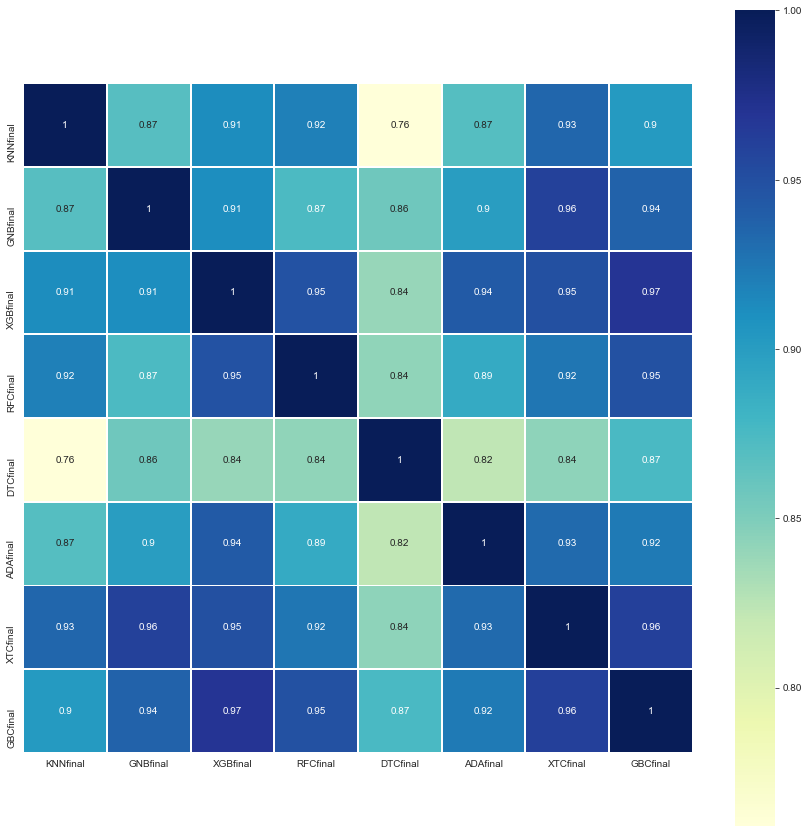

```python
plt.figure(figsize= (15,15))
sns.heatmap(corr_table.corr(),
            #mask= corr_table.corr() <0.8,
            cmap="YlGnBu",
            linewidths = 1,
            square = True,
            annot=True)
```